# Homework 4

Wenxiao Yang

## Multiple Linear Regression

### Part II: Homework Questions – to be submitted

The `whitewines.csv` data set contains information related to white variants of the Portuguese “Vinho Verde” wine. Specifically, we have recorded the following information:

1. fixed acidity, (b) volatile acidity, (c) citric acid, (d) residual sugar, (e) chlorides , (f) free sulfur dioxide, (g) total sulfur dioxide, (h) density, (i) pH, (j) sulphates, (k) alcohol, (l) quality (score between 0 and 10)

In this homework, our goal is to explain the relationship between alcohol level (dependent variable) and residual sugar, pH, density and fixed acidity.

1. Identify any outlying $Y$ observations. Use the Bonferroni outlier test procedure with $\alpha=.05$. State decision rule and conclusion.

   ```r
   whitewines<-read.csv("whitewines.csv",sep = ";")
   whitewines.reg=whitewines[,c(-2,-3,-5,-6,-7,-10,-12)]
   whitewines.mlr=lm(alcohol~residual.sugar+pH+density+fixed.acidity,data=whitewines.reg)
   summary(whitewines.mlr)
   ```

   ```
   ##
   ## Call:
   ## lm(formula = alcohol ~ residual.sugar + pH + density + fixed.acidity,
   ##     data = whitewines.reg)
   ##
   ## Residuals:
   ##     Min      1Q  Median      3Q     Max
   ## -3.3867 -0.2735 -0.0334  0.2200 16.9366
   ##
   ## Coefficients:
   ##                  Estimate Std. Error t value Pr(>|t|)
   ## (Intercept)     6.790e+02  4.540e+00  149.56   <2e-16 ***
   ## residual.sugar  2.367e-01  2.702e-03   87.58   <2e-16 ***
   ## pH              2.535e+00  5.281e-02   48.01   <2e-16 ***
   ## density        -6.858e+02  4.664e+00 -147.05   <2e-16 ***
   ## fixed.acidity   5.352e-01  9.858e-03   54.30   <2e-16 ***
   ## ---
   ## Signif. codes:  0 '***' 0.001 '**' 0.01 '*' 0.05 '.' 0.1 ' ' 1
   ##
   ## Residual standard error: 0.4702 on 4893 degrees of freedom
   ## Multiple R-squared:  0.8542, Adjusted R-squared:  0.854
   ## F-statistic:  7164 on 4 and 4893 DF,  p-value: < 2.2e-16
   ```

   ```r
   n=dim(whitewines.reg)[1]
   p=5
   qt(0.05/(2*n),n-p-1)
   ```

   ```
   ## [1] -4.417336
   ```

   ```r
   rst_whitewines=rstudent(whitewines.mlr)
   sort(rst_whitewines, decreasing = TRUE)[1:10]
   ```

   ```
   ##      2782      3902      1654      1664      1418      2732      3620      3624
   ## 43.513422  8.425736  6.464412  6.464412  4.103559  4.093453  4.068846  4.068846
   ##      2731      4816
   ##  4.060125  3.574727
   ```

   If the absolute value of Studentized Residuals is higer than the absolute value of the critical $T$ distribution value with Bonferroni correction (i.e. $|-4.417336|$). We have 4 outliers: #2782, $3902, #1654, #1664.
2. Obtain the diagonal elements of the hat matrix and identify any high leverage points. If any, are they good or bad?

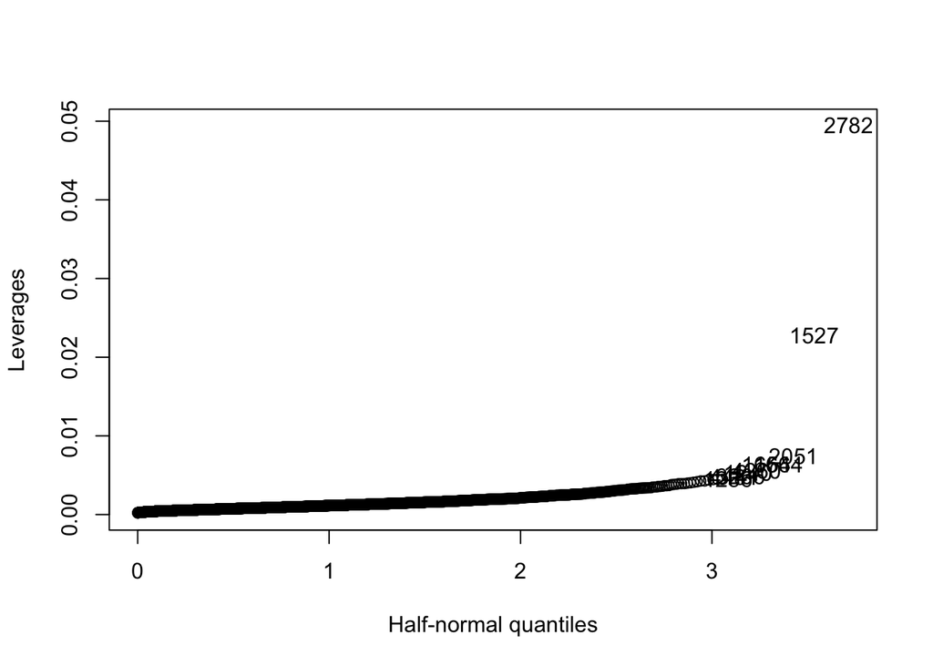

   ```r
   library(faraway)
   h_vec=influence(whitewines.mlr)$hat
   halfnorm(h_vec, 10, ylab="Leverages")
   ```

   ```r
   high_lev=h_vec[h_vec>2*p/n]
   length(high_lev)
   ```

   ```
   ## [1] 247
   ```

   There are 247 high leverage points. If a point’s $y$ value follows the pattern of the rest of the data, then it is a good-high leverage point, otherwise, it is not.
3. Use Cook’s distance to investigate whether there are any high influential points. What do you conclude?

   ```r
   cook=cooks.distance(whitewines.mlr)
   cook[cook>1]
   ```

   ```
   ##     2782
   ## 14.23251
   ```

   There is a high influential point #2782. It is much larger than the other samples.
4. Calculate Cook’s distance $D_i$ for each case and prepare an index plot. Are any cases influential according to this measure?

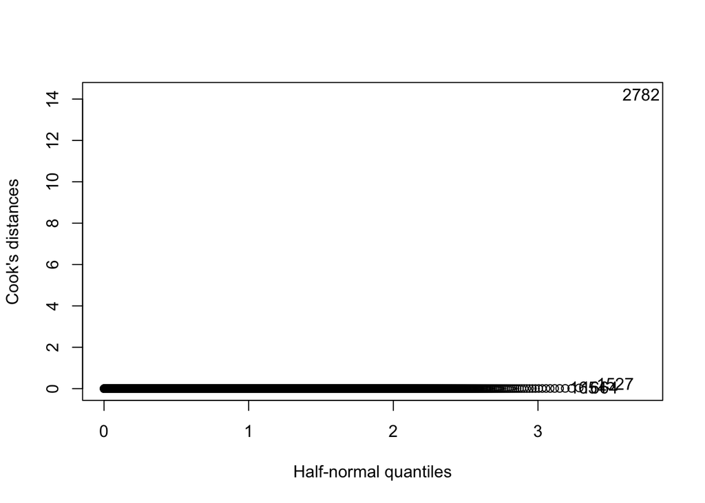

   ```r
   cook=cooks.distance(whitewines.mlr)
   halfnorm(cook, 4, ylab="Cook's distances")
   ```

   #2782 is high influential.
5. Predict the amount of alcohol of a white wine with residual.sugar = 1.7 , pH = 3, density = 1, fixed.acidity = 6.3 with an appropriate 95% confidence interval.

   ```r
   new=data.frame(residual.sugar = 1.7 , pH = 3, density = 1, fixed.acidity = 6.3)
   predict.lm(whitewines.mlr,new,interval = "confidence", level=0.95)
   ```

   ```
   ##        fit      lwr      upr
   ## 1 4.533544 4.440764 4.626325
   ```

6. Predict the amount of alcohol of a white wine with residual.sugar = 67 , pH = 4, density = 1.1, fixed.acidity = 15 with an appropriate 95% prediction interval.

   ```r
   new2=data.frame(residual.sugar = 67 , pH = 4, density = 1.1, fixed.acidity = 15)
   predict.lm(whitewines.mlr,new2,interval = "prediction", level=0.95)
   ```

   ```
   ##         fit       lwr       upr
   ## 1 -41.40047 -42.52562 -40.27533
   ```

7. Construct a 95% confidence region for the slope coefficients of pH and density. What do you conclude about the statistical significance of $\beta_{pH}$ and $\beta_{density}$?

   ```r
   library(ellipse)
   ```

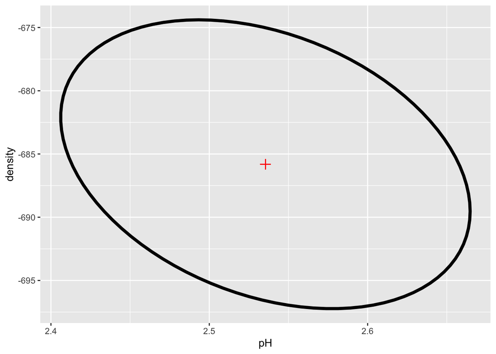

   ```r
   library(ggplot2)
   CR95 = ellipse(whitewines.mlr, c(3,4), level=0.95)
   CR95=data.frame(CR95)
   ggplot(data=CR95, aes(x=pH, y=density)) +
     geom_path(size=1.5) +
     geom_point(x=coef(whitewines.mlr)[3], y=coef(whitewines.mlr)[4], shape=3, size=3, colour='red')
   ```

   Obviously, $\beta_{pH}$ and $\beta_{density}$ are statistical significant at $95\%$ level.
8. Regress `alcohol` against `fixed acidity` and construct a 95% simultaneous confidence band for the fitted regression line.

   ```r
   whitewines.mlr2=lm(alcohol~fixed.acidity,data=whitewines.reg)
   confint(whitewines.mlr2)
   ```

   ```
   ##                    2.5 %    97.5 %
   ## (Intercept)   11.4425207 12.002765
   ## fixed.acidity -0.2168411 -0.135723
   ```

   ```r
   mlr2.band=predict(whitewines.mlr2, interval = "confidence")
   mlr2.band=data.frame(mlr2.band)
   mlr2.band$lwr=mlr2.band$fit-(mlr2.band$fit-mlr2.band$lwr)*sqrt(2*qf(0.05,2,n-2,lower.tail=FALSE))/abs(qt(0.025,n-2))
   mlr2.band$upr=mlr2.band$fit+(mlr2.band$upr-mlr2.band$fit)*sqrt(2*qf(0.05,2,n-2,lower.tail=FALSE))/abs(qt(0.025,n-2))
   head(mlr2.band)
   ```

   ```
   ##        fit      lwr      upr
   ## 1 10.48867 10.44530 10.53204
   ## 2 10.61207 10.56091 10.66322
   ## 3 10.29476 10.21856 10.37095
   ## 4 10.45341 10.40723 10.49959
   ## 5 10.45341 10.40723 10.49959
   ## 6 10.29476 10.21856 10.37095
   ```

9. Plot the raw data corresponding to question (h), fitted regression line, 95% point-wise confidence intervals and 95% confidence band calculated in (h). What do you observe?

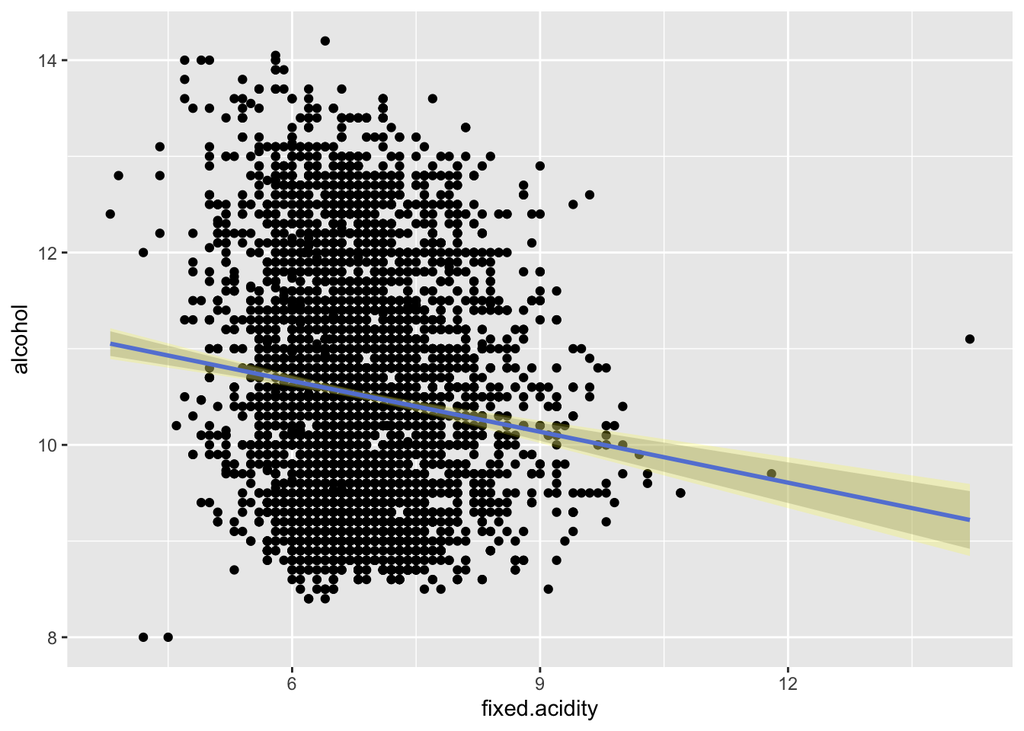

   ```r
   library(ggplot2)
   ggplot(whitewines.reg,aes(fixed.acidity,alcohol))+geom_point()+geom_smooth(method=lm)+geom_ribbon( aes(ymin=mlr2.band$lwr,ymax=mlr2.band$upr),alpha = 0.2, fill="yellow")
   ```

   The confidence band is wider than the point-wise the confidence interval.